# Анализ оттока клиентов банка

## Описание проекта

В банке «Метанпромбанк» последнее время значительно повысился отток клиентов, это начинает становиться проблемой, которая угрожает существованию банка. Привлекать новых клиентов дорого, дешевле удержать тех, которых банк уже знает и с которыми работает.

Отделу маркетинга банка необходимы результаты анализа оттока клиентов, которые покажут, какие клиенты уходят из банка, а так же позволит составить сегменты клиентов, которые склонны уходить из банка.

Информация нужна менеджеру, который занимается маркетиновыми кампаниями и работает в тесной связке с менеджерами продуктов. Поскольку в отделе маркетинга нет автоматизированных систем рассылок и письма каждому клиенту пишутся вручную, необходимо максимально эффективно выделить сегменты отточных клиентов, чтобы они были однородными, высокоотточными и покрывали максимум проблемных зон банка. Таким образом, маркетинговое воздействие на эти сегменты будет максимально эффективным и должно будет привести к уменьшению оттока.

Также необходимо дать рекомендации по мероприятиям, которые можно провести, чтобы вернуть клиентов в банк или удержать сомневающихся от оттока.

Ранее уже проводилось подобное исследование, но его результаты устарели и по ним не возможно выяснить, в чём сейчас заключается проблема и как её можно решить. Кроме этого, состав клиентов банка изменился и старые сегменты больше не подходят.

## Описание данных

Датасет `bank_scrooge.csv` содержит данные о клиентах банка «Метанпром». Банк располагается в Ярославле и областных городах Ростов Великий и Рыбинск.

- USERID — идентификатор пользователя,
- score — баллы кредитного скоринга,
- city — город,
- gender — пол,
- age — возраст,
- equity — приблизительная оценка собственности клиента,
- balance — баланс на счёте,
- products — количество продуктов, которыми пользуется клиент,
- credit_card — есть ли кредитная карта,
- last_activity — был ли клиент активен последнее время,
- EST_SALARY — оценочная заработная плата клиента,
- сhurn — признак оттока.

## Последовательность выполнения проекта

### Открыть файл с данными и изучить общую информацию

Путь к файлу: `/datasets/bank_scrooge.csv`

### Подготовить данные

- Привести названия столбцов к `snake_case`;
- Проверить датасет на наличие пропусков и провести их анализ;
- Привести типы данных в столбцах в соответствие с содержащейся в них информацией;
- Проверить датасет на наличие дубликатов и провести их анализ;
- Добавить столбец с обозначением пола:
  - 0 - женщина;
  - 1 - мужчина;
- Добавить столбцы с принадлежностью клиента к городу методом кодирования с помощью эффективных переменных.
- Написать промежуточные выводы.

### Провести исследовательский анализ данных

- Сравнить портреты типичных клиентов. Сравнить средние и медианные значения количественных признаков отточных и неотточных клиентов;
- Изучить распределение непрерывных данных (баланса, зарпаты, кредитного скорринга и возраста) отточных и неотточных клиентов;
- Изучить долю оттока по категориям пользователей;
- Провести корреляционный анализ;
- Написать промежуточные выводы.

### Проверить статистические гипотезы

- Проверить гипотезу различия дохода между отточными и неотточными клиентами;
- Проверить гипотезу различия баланса между отточными и неотточными клиентами;
- Проверим гипотезу о равенстве доли мужчин и женщин среди отточных и неотточных клиентов;
- Проверим гипотезу о равенстве доли клиентов с кредитной картой среди отточных и неотточных клиентов.
- Написать промежуточные выводы.

### Подвести промежуточный итог

Выделить, какие признаки стратегическим образом влияют на отток и какие значения или интервалы этих признаков связаны с оттоком.

### Провести сегментацию пользователей на основе стратегических показателей

- Выделить компактные высокоотточные сегменты пользователей (группы пользователей, объединенные несколькими признаками);
- Посчитать размер и отток сегментов;
- Сравнить отток сегментов с общим оттоком;
- Приоритизировать сегменты;
- Написать промежуточные выводы.

### Написать общие выводы и рекомендации

Написать общие выводы по результатам исследования и дать рекомендации, какие мероприятия можно провести, чтобы вернуть клиентов в банк или удержать сомневающихся от ухода.

### Подготовить презентацию с результататми анализа данных

Ссылку на презентацию добавить в начало тетради.

# Выполнение проекта

**Материалы**

[Презентация](https://disk.yandex.ru/i/whhLdU8ABqm2nA)

## Загрузка данных и изучение информации

Загрузим библиотеки, которые будем использовать в проекте.

```python
!pip install phik
```

```python
import pandas as pd
import matplotlib.pyplot as plt
import seaborn as sns
import phik
from scipy import stats as st
import math as mth
import numpy as np
```

Считаем данные из csv-файла в датафрейм и сохраним в пременную bank. Путь к файлу: /datasets/bank_scrooge.csv

```python
bank = pd.read_csv('/datasets/bank_scrooge.csv')
```

Зададим функцию для вывода всей информации о таблице.

```python
def df_info(df):
    print('\033[1m' + 'Первые 20 строк таблицы:' + '\033[0m')
    display(df.head(20))
    print()
    print('\033[1m' + 'Общая информация о таблице:' + '\033[0m')
    print(df.info())
    print()
    is_na_amt = df.isna().sum()
    is_na_percent = round(df.isnull().sum().sort_values()/ len(df)*100, 2)
    is_na = pd.concat([is_na_amt, is_na_percent], axis=1)
    is_na.columns=(['Количество пропусков', '% пропусков'])
    print('\033[1m' + 'Информация о пропусках в таблице:' + '\033[0m')
    display(is_na)
    print()
    print('\033[1m' + 'Количество дубликатов в таблице:' + '\033[0m')
    print(df.duplicated().sum())
```

Выведем основную информацию о датафрейме `bank`.

```python
df_info(bank)
```

```
Первые 20 строк таблицы:
```

|  | USERID | score | city | gender | age | equity | balance | products | credit_card | last_activity | EST_SALARY | churn |
| --- | --- | --- | --- | --- | --- | --- | --- | --- | --- | --- | --- | --- |
| 0 | 183012 | 850.0 | Рыбинск | Ж | 25.0 | 1 | 59214.82 | 2 | 0 | 1 | 75719.14 | 1 |
| 1 | 146556 | 861.0 | Рыбинск | Ж | 37.0 | 5 | 850594.33 | 3 | 1 | 0 | 86621.77 | 0 |
| 2 | 120722 | 892.0 | Рыбинск | Ж | 30.0 | 0 | NaN | 1 | 1 | 1 | 107683.34 | 0 |
| 3 | 225363 | 866.0 | Ярославль | Ж | 51.0 | 5 | 1524746.26 | 2 | 0 | 1 | 174423.53 | 1 |
| 4 | 157978 | 730.0 | Ярославль | М | 34.0 | 5 | 174.00 | 1 | 1 | 0 | 67353.16 | 1 |
| 5 | 202305 | 856.0 | Рыбинск | М | 56.0 | 4 | 863687.24 | 3 | 1 | 0 | 156619.80 | 0 |
| 6 | 177259 | 807.0 | Ярославль | Ж | 39.0 | 3 | 405042.44 | 3 | 0 | 1 | 103838.32 | 0 |
| 7 | 218868 | 825.0 | Ярославль | Ж | 38.0 | 4 | 458145.40 | 2 | 1 | 1 | 68085.48 | 0 |
| 8 | 211686 | 923.0 | Ярославль | М | 54.0 | 5 | 1206337.87 | 2 | 1 | 0 | 155371.79 | 0 |
| 9 | 133130 | 906.0 | Ярославль | Ж | 67.0 | 0 | NaN | 1 | 0 | 1 | 238055.53 | 0 |
| 10 | 148929 | 927.0 | Ростов | М | 52.0 | 0 | NaN | 1 | 1 | 1 | 196820.07 | 0 |
| 11 | 172184 | 921.0 | Ростов | М | 41.0 | 0 | NaN | 1 | 1 | 1 | 217469.48 | 0 |
| 12 | 132970 | 845.0 | Ярославль | Ж | 31.0 | 3 | 591928.52 | 2 | 1 | 1 | 112697.16 | 1 |
| 13 | 166357 | 837.0 | Рыбинск | Ж | 28.0 | 4 | 302249.22 | 2 | 0 | 1 | 30950.94 | 0 |
| 14 | 172138 | 815.0 | Ярославль | М | 35.0 | 5 | 547499.87 | 2 | 1 | 1 | 105883.26 | 0 |
| 15 | 120260 | 731.0 | Рыбинск | М | 42.0 | 3 | 1480548.47 | 3 | 1 | 0 | 160974.43 | 0 |
| 16 | 123335 | 829.0 | Ярославль | М | 45.0 | 5 | 507842.84 | 1 | 1 | 1 | 169330.64 | 0 |
| 17 | 214277 | 793.0 | Ярославль | М | 53.0 | 3 | 627034.50 | 2 | 1 | 0 | 183430.19 | 0 |
| 18 | 136651 | 876.0 | Ярославль | М | 40.0 | 5 | 2307947.36 | 2 | 0 | 0 | 287010.61 | 0 |
| 19 | 127034 | 922.0 | Рыбинск | Ж | 53.0 | 0 | NaN | 1 | 0 | 0 | 147094.82 | 0 |

```
Общая информация о таблице:
<class 'pandas.core.frame.DataFrame'>
RangeIndex: 10000 entries, 0 to 9999
Data columns (total 12 columns):
 #   Column         Non-Null Count  Dtype
---  ------         --------------  -----
 0   USERID         10000 non-null  int64
 1   score          10000 non-null  float64
 2   city           10000 non-null  object
 3   gender         10000 non-null  object
 4   age            9974 non-null   float64
 5   equity         10000 non-null  int64
 6   balance        7705 non-null   float64
 7   products       10000 non-null  int64
 8   credit_card    10000 non-null  int64
 9   last_activity  10000 non-null  int64
 10  EST_SALARY     10000 non-null  float64
 11  churn          10000 non-null  int64
dtypes: float64(4), int64(6), object(2)
memory usage: 937.6+ KB
None

Информация о пропусках в таблице:
```

|  | Количество пропусков | % пропусков |
| --- | --- | --- |
| USERID | 0 | 0.00 |
| score | 0 | 0.00 |
| city | 0 | 0.00 |
| gender | 0 | 0.00 |
| age | 26 | 0.26 |
| equity | 0 | 0.00 |
| balance | 2295 | 22.95 |
| products | 0 | 0.00 |
| credit_card | 0 | 0.00 |
| last_activity | 0 | 0.00 |
| EST_SALARY | 0 | 0.00 |
| churn | 0 | 0.00 |

```
Количество дубликатов в таблице:
0
```

Датасет содержит 10000 строк и 12 столбцов. Есть 26 пропусков в столбце `age` и 2295 пропусков в столбце `balance`. Явные дубликаты отсутствуют.

## Подготовка данных

Не все названия столбцов в `snake_case`. Исправим это.

```python
bank = bank.rename(columns={'USERID':'user_id', 'EST_SALARY':'est_salary'})
```

Столбец `age` содержит 0.26% пропусков, изучим эти строки.

```python
bank[bank['age'].isna()]
```

|  | user_id | score | city | gender | age | equity | balance | products | credit_card | last_activity | est_salary | churn |
| --- | --- | --- | --- | --- | --- | --- | --- | --- | --- | --- | --- | --- |
| 1247 | 228075 | 932.0 | Ярославль | М | NaN | 5 | 7601719.20 | 2 | 1 | 1 | 408121.16 | 0 |
| 2165 | 187635 | 692.0 | Рыбинск | Ж | NaN | 0 | NaN | 1 | 1 | 1 | 160368.82 | 0 |
| 2444 | 221156 | 913.0 | Ярославль | М | NaN | 0 | NaN | 1 | 1 | 1 | 135693.24 | 0 |
| 3091 | 138660 | 836.0 | Ростов | Ж | NaN | 5 | 294315.53 | 2 | 0 | 1 | 63310.22 | 1 |
| 4912 | 210674 | 834.0 | Рыбинск | М | NaN | 1 | 238330.52 | 2 | 0 | 1 | 93775.06 | 0 |
| 5470 | 218868 | 827.0 | Рыбинск | Ж | NaN | 4 | 448959.07 | 2 | 1 | 1 | 67835.95 | 0 |
| 5495 | 151662 | 884.0 | Рыбинск | Ж | NaN | 0 | NaN | 1 | 1 | 1 | 137500.77 | 0 |
| 7236 | 210135 | 908.0 | Рыбинск | Ж | NaN | 4 | 1120340.31 | 3 | 1 | 1 | 85002.15 | 0 |
| 7248 | 219343 | 920.0 | Рыбинск | Ж | NaN | 0 | NaN | 1 | 1 | 0 | 159248.67 | 0 |
| 7345 | 184913 | 829.0 | Ярославль | Ж | NaN | 3 | 188648.77 | 2 | 0 | 1 | 75206.90 | 0 |
| 7409 | 214031 | 777.0 | Ярославль | М | NaN | 2 | 171510.23 | 1 | 1 | 1 | 75409.63 | 0 |
| 8015 | 198635 | 670.0 | Ярославль | Ж | NaN | 0 | NaN | 1 | 1 | 1 | 168699.33 | 0 |
| 8070 | 226550 | 940.0 | Рыбинск | М | NaN | 0 | NaN | 1 | 0 | 1 | 147696.95 | 0 |
| 8293 | 216848 | 930.0 | Ярославль | М | NaN | 0 | NaN | 1 | 1 | 1 | 199542.51 | 0 |
| 8385 | 206759 | 915.0 | Рыбинск | М | NaN | 0 | NaN | 1 | 1 | 0 | 71179.53 | 0 |
| 8449 | 210898 | 805.0 | Ярославль | Ж | NaN | 0 | NaN | 1 | 0 | 1 | 922080.25 | 0 |
| 8632 | 221197 | 893.0 | Ярославль | М | NaN | 0 | NaN | 1 | 1 | 0 | 173929.92 | 0 |
| 8785 | 127440 | 663.0 | Ярославль | М | NaN | 0 | NaN | 1 | 1 | 1 | 117197.56 | 0 |
| 9104 | 222480 | 776.0 | Рыбинск | Ж | NaN | 5 | 796735.09 | 1 | 1 | 1 | 55073.63 | 0 |
| 9301 | 202983 | 942.0 | Рыбинск | Ж | NaN | 0 | NaN | 1 | 1 | 1 | 163804.73 | 0 |
| 9380 | 187459 | 894.0 | Рыбинск | М | NaN | 0 | NaN | 1 | 1 | 0 | 178012.28 | 0 |
| 9457 | 141945 | 929.0 | Ярославль | М | NaN | 0 | NaN | 1 | 1 | 0 | 381868.89 | 0 |
| 9632 | 185829 | 927.0 | Ярославль | М | NaN | 0 | NaN | 1 | 1 | 0 | 231254.86 | 0 |
| 9634 | 221809 | 917.0 | Ярославль | М | NaN | 0 | NaN | 1 | 1 | 1 | 192644.15 | 0 |
| 9667 | 163657 | 849.0 | Ярославль | М | NaN | 4 | 1254013.85 | 2 | 1 | 1 | 119106.67 | 0 |
| 9819 | 140934 | 832.0 | Рыбинск | Ж | NaN | 3 | 385763.16 | 2 | 0 | 1 | 59651.35 | 0 |

Скорее всего пропуски возникли случайным образом. Поскольку пропусков мало, можно заполнить их медианным значением по столбцу `age`, это не повлияет на дальнейший анализ.

```python
median_age = bank['age'].median()
bank['age'].fillna(median_age, inplace=True)
```

Столбец `balance` содержит 22.95% пропусков. Такой большой процент пропусков невозможно удалить из данных, т.к. это повлияет на дальнейший анализ. Изучим эти строки.

```python
bank_balance_isna = bank[bank['balance'].isna()]
bank_balance_isna.head(20)
```

|  | user_id | score | city | gender | age | equity | balance | products | credit_card | last_activity | est_salary | churn |
| --- | --- | --- | --- | --- | --- | --- | --- | --- | --- | --- | --- | --- |
| 2 | 120722 | 892.0 | Рыбинск | Ж | 30.0 | 0 | NaN | 1 | 1 | 1 | 107683.34 | 0 |
| 9 | 133130 | 906.0 | Ярославль | Ж | 67.0 | 0 | NaN | 1 | 0 | 1 | 238055.53 | 0 |
| 10 | 148929 | 927.0 | Ростов | М | 52.0 | 0 | NaN | 1 | 1 | 1 | 196820.07 | 0 |
| 11 | 172184 | 921.0 | Ростов | М | 41.0 | 0 | NaN | 1 | 1 | 1 | 217469.48 | 0 |
| 19 | 127034 | 922.0 | Рыбинск | Ж | 53.0 | 0 | NaN | 1 | 0 | 0 | 147094.82 | 0 |
| 21 | 177415 | 896.0 | Рыбинск | Ж | 47.0 | 0 | NaN | 1 | 0 | 0 | 225060.35 | 0 |
| 30 | 155730 | 946.0 | Ярославль | Ж | 47.0 | 0 | NaN | 2 | 1 | 1 | 660015.85 | 0 |
| 34 | 205226 | 944.0 | Ярославль | М | 35.0 | 0 | NaN | 2 | 1 | 1 | 239843.39 | 0 |
| 39 | 173175 | 924.0 | Рыбинск | Ж | 51.0 | 0 | NaN | 1 | 1 | 1 | 248844.47 | 0 |
| 43 | 228585 | 956.0 | Ростов | М | 41.0 | 0 | NaN | 1 | 1 | 0 | 115117.10 | 0 |
| 46 | 118927 | 921.0 | Ярославль | Ж | 72.0 | 1 | NaN | 1 | 1 | 0 | 253494.70 | 0 |
| 52 | 214266 | 888.0 | Ярославль | Ж | 37.0 | 0 | NaN | 2 | 0 | 0 | 149164.44 | 0 |
| 57 | 167752 | 914.0 | Ростов | Ж | 58.0 | 0 | NaN | 2 | 1 | 0 | 116651.71 | 0 |
| 59 | 227642 | 930.0 | Ярославль | Ж | 36.0 | 0 | NaN | 2 | 1 | 0 | 359081.73 | 0 |
| 60 | 191602 | 944.0 | Ярославль | Ж | 71.0 | 0 | NaN | 2 | 0 | 1 | 107801.19 | 0 |
| 62 | 128486 | 922.0 | Рыбинск | Ж | 55.0 | 0 | NaN | 2 | 1 | 0 | 146005.18 | 0 |
| 66 | 224917 | 737.0 | Ярославль | Ж | 54.0 | 1 | NaN | 1 | 1 | 0 | 113173.05 | 0 |
| 68 | 216960 | 933.0 | Ярославль | М | 49.0 | 1 | NaN | 1 | 1 | 1 | 130281.88 | 0 |
| 86 | 153632 | 750.0 | Ростов | М | 45.0 | 0 | NaN | 1 | 1 | 0 | 296397.19 | 0 |
| 101 | 184435 | 921.0 | Ростов | Ж | 42.0 | 0 | NaN | 1 | 1 | 0 | 232353.50 | 0 |

```python
bank_balance_isna.drop('user_id', axis=1).describe()
```

|  | score | age | equity | balance | products | credit_card | last_activity | est_salary | churn |
| --- | --- | --- | --- | --- | --- | --- | --- | --- | --- |
| count | 2295.000000 | 2295.000000 | 2295.000000 | 0.0 | 2295.000000 | 2295.000000 | 2295.000000 | 2.295000e+03 | 2295.000000 |
| mean | 865.352070 | 42.078431 | 0.050980 | NaN | 1.162092 | 0.815686 | 0.549455 | 2.263102e+05 | 0.005664 |
| std | 89.603091 | 11.901109 | 0.225872 | NaN | 0.402532 | 0.387824 | 0.497657 | 1.997718e+05 | 0.075066 |
| min | 642.000000 | 18.000000 | 0.000000 | NaN | 0.000000 | 0.000000 | 0.000000 | 2.027403e+04 | 0.000000 |
| 25% | 871.000000 | 33.000000 | 0.000000 | NaN | 1.000000 | 1.000000 | 0.000000 | 1.203477e+05 | 0.000000 |
| 50% | 903.000000 | 40.000000 | 0.000000 | NaN | 1.000000 | 1.000000 | 1.000000 | 1.741607e+05 | 0.000000 |
| 75% | 922.000000 | 49.000000 | 0.000000 | NaN | 1.000000 | 1.000000 | 1.000000 | 2.400150e+05 | 0.000000 |
| max | 990.000000 | 86.000000 | 3.000000 | NaN | 3.000000 | 1.000000 | 1.000000 | 1.333687e+06 | 1.000000 |

```python
bank_balance_na = bank[['balance', 'score', 'age', 'equity', 'credit_card', 'products', 'last_activity', 'est_salary']]
bank_balance_na['balance_na'] = np.where(bank_balance_na['balance'].isnull(), 0,1)
bank_balance_na = bank_balance_na.drop('balance', axis=1)
bank_balance_na.groupby('balance_na').agg({'score':'mean',
                                           'age':'mean',
                                           'equity':'mean',
                                           'credit_card':'mean',
                                           'products':'mean',
                                           'last_activity':'mean',
                                           'est_salary':'mean'})
```

| balance_na | score | age | equity | credit_card | products | last_activity | est_salary |
| --- | --- | --- | --- | --- | --- | --- | --- |
| 0 | 865.35207 | 42.078431 | 0.050980 | 0.815686 | 1.162092 | 0.549455 | 226310.208654 |
| 1 | 843.73926 | 42.920571 | 3.395068 | 0.640104 | 2.080986 | 0.515769 | 124501.872366 |

Видим, что клиенты с пропуском значения баланса являются владельцами единственного продукта - кредитной карты, в то аремя, как клиенты без пропуска в среднем имеют по 2 продукта банка, что не исключает, что они также владеют кредитной картой (поскольку 64.0% пользователей без пропуска в значении баланса владеют кредитной картой), но кроме этого, у них есть второй продукт банка, связанный с наличием счета (вклад или дебетовая карта). Кроме этого, есть явное различие по оценке собственности клиента - у клиентов с пропуском значения баланса среднее значение этого признака 0.05, в то время, как у клиентов без пропуска это значение равно 3.4. Это может быть связано как с отсутствием или непредоставлением информации клиентами, так и с объективной оценкой собственности клиента или высокой закредитованностью, т.к. у клиента может быть кредит или кредитная карат не только в банке «Метанпромбанк». При этом средняя зарплата клиентов с пропуском значения баланса почти в 2 раза выше, чем у клиентов без пропуска - 226310.21 р. и 124501.87 р. соответственно. По остальным признакам - кредитному скорингу, возрату, активности в последнее время - между клиентами значимых отличий нет.

Изучим корреляцию баланса, наличия кредитной карты и количества продуктов.

```python
bank_balance_na.corr()
```

|  | score | age | equity | credit_card | products | last_activity | est_salary | balance_na |
| --- | --- | --- | --- | --- | --- | --- | --- | --- |
| score | 1.000000 | -0.011847 | 0.064126 | -0.094732 | -0.004115 | -0.031179 | 0.163866 | -0.138871 |
| age | -0.011847 | 1.000000 | 0.020957 | -0.123095 | 0.017547 | -0.008434 | -0.039643 | 0.029112 |
| equity | 0.064126 | 0.020957 | 1.000000 | -0.167506 | 0.432069 | -0.001970 | -0.171974 | 0.709951 |
| credit_card | -0.094732 | -0.123095 | -0.167506 | 1.000000 | -0.251390 | -0.033445 | 0.035556 | -0.158334 |
| products | -0.004115 | 0.017547 | 0.432069 | -0.251390 | 1.000000 | 0.037141 | -0.118054 | 0.487512 |
| last_activity | -0.031179 | -0.008434 | -0.001970 | -0.033445 | 0.037141 | 1.000000 | 0.003039 | -0.028362 |
| est_salary | 0.163866 | -0.039643 | -0.171974 | 0.035556 | -0.118054 | 0.003039 | 1.000000 | -0.307154 |
| balance_na | -0.138871 | 0.029112 | 0.709951 | -0.158334 | 0.487512 | -0.028362 | -0.307154 | 1.000000 |

Корреляция с наличием кредитной карты слабая (-15.8%), поскольку кредитными картами владеют не только клиенты с пропуском значения баланса, что не удивительно, т.к. кредитная карта является самым популярным банковским продуктом среди населения. А вот корреляция с количеством продуктов присутствует (49.0%). Самая высокая корреляция с оценкой собственности (71.0%), т.к. почти все клиенты с пропуском значения баланса имеют оценку 0, что сильно отличается от остальных клиентов. С остальными признаками корреляциия либо слабая, либо отсутствует совсем: кредитный скоринг (-13.9%), возраст (2.9%), активность (-2.8%), зарплата (-30.7%).

Пропуски в столбце `balance` появились не случайно, они зависят от других данных. По общепринятой классификацией пропусков такие пропуски можно отнести к категории MNAR (Missing Not At Random/Отсутствует не случайно). В данном случае следует понимать пропуски в столбце `balance`, как баланс равный 0. Это пользователи, которые не держут деньги на счете в банке «Метанпромбанк», а пользуются кредитной картой банка. Проведем соответствующую замену.

```python
bank['balance'] = bank['balance'].fillna(0)
```

Значение кредитного скорринга и возраст это целые числа, изменим тип данных у этих столбцов на `int`.

```python
bank[['score', 'age']] = bank[['score', 'age']].astype(int)
```

Проверим наличие дубликатов в столбце `user_id`.

```python
print('В столбце user_id количество дубликатов равно', bank['user_id'].duplicated().sum())
```

```
В столбце user_id количество дубликатов равно 73
```

Проверим, сколько всего дублиованных значений в столбце `user_id`.

```python
print('В столбце user_id количество дублиованных значений', bank['user_id'].duplicated(keep=False).sum())
```

```
В столбце user_id количество дублиованных значений 146
```

В датасете есть 73 user_id, каждый из которых указан дважды. Изучим эти строки.

```python
bank[bank['user_id'].duplicated(keep=False)].sort_values(by='user_id').head(20)
```

|  | user_id | score | city | gender | age | equity | balance | products | credit_card | last_activity | est_salary | churn |
| --- | --- | --- | --- | --- | --- | --- | --- | --- | --- | --- | --- | --- |
| 1893 | 116540 | 883 | Рыбинск | Ж | 55 | 1 | 362756.49 | 3 | 0 | 1 | 175920.48 | 1 |
| 7694 | 116540 | 887 | Ярославль | Ж | 38 | 0 | 0.00 | 1 | 0 | 1 | 119247.61 | 0 |
| 7542 | 117943 | 880 | Ярославль | Ж | 40 | 0 | 0.00 | 1 | 1 | 0 | 137718.93 | 0 |
| 4866 | 117943 | 855 | Рыбинск | Ж | 32 | 6 | 1036832.93 | 4 | 1 | 1 | 107792.71 | 1 |
| 5896 | 120258 | 905 | Ярославль | М | 30 | 0 | 0.00 | 1 | 1 | 1 | 146427.96 | 0 |
| 5863 | 120258 | 908 | Рыбинск | Ж | 38 | 4 | 2213581.63 | 2 | 0 | 1 | 160327.77 | 1 |
| 1411 | 123461 | 829 | Ярославль | Ж | 59 | 0 | 96222.44 | 2 | 0 | 1 | 102771.55 | 1 |
| 8638 | 123461 | 934 | Рыбинск | М | 34 | 0 | 0.00 | 2 | 1 | 0 | 291619.27 | 0 |
| 8164 | 124450 | 859 | Ярославль | Ж | 38 | 6 | 516811.20 | 1 | 1 | 1 | 95144.63 | 1 |
| 9775 | 124450 | 758 | Рыбинск | Ж | 36 | 0 | 73574.07 | 2 | 0 | 1 | 79963.59 | 0 |
| 4850 | 126368 | 909 | Ярославль | Ж | 30 | 4 | 1322623.29 | 2 | 0 | 1 | 140675.66 | 1 |
| 5420 | 126368 | 832 | Рыбинск | Ж | 33 | 0 | 0.00 | 1 | 0 | 0 | 118465.34 | 0 |
| 8785 | 127440 | 663 | Ярославль | М | 40 | 0 | 0.00 | 1 | 1 | 1 | 117197.56 | 0 |
| 4443 | 127440 | 846 | Рыбинск | М | 66 | 1 | 57405.67 | 2 | 0 | 1 | 17831.63 | 0 |
| 3988 | 129785 | 904 | Рыбинск | М | 33 | 5 | 2427737.60 | 3 | 0 | 1 | 188856.75 | 1 |
| 9504 | 129785 | 949 | Ярославль | М | 43 | 0 | 0.00 | 1 | 1 | 1 | 166845.37 | 0 |
| 904 | 131419 | 934 | Ярославль | М | 35 | 5 | 2348335.95 | 2 | 0 | 0 | 217105.13 | 1 |
| 2138 | 131419 | 739 | Рыбинск | Ж | 37 | 3 | 1307941.65 | 3 | 0 | 0 | 103867.47 | 0 |
| 7487 | 140377 | 930 | Рыбинск | Ж | 34 | 5 | 1123967.02 | 1 | 1 | 1 | 148336.26 | 0 |
| 1608 | 140377 | 802 | Ярославль | М | 26 | 3 | 539863.29 | 4 | 1 | 1 | 112167.83 | 1 |

Проверим наличие неявных дубликатов в столбце `city`.

```python
bank['city'].unique()
```

```
array(['Рыбинск', 'Ярославль', 'Ростов'], dtype=object)
```

В столбце `city` неявные дубликаты отсутствуют.

Добавим столбец с обозначением пола (0 - женщина, 1 - мужчина)

```python
bank['gender_dum'] = bank['gender']
bank = pd.get_dummies(bank, columns=['gender_dum'], drop_first=True)
```

Добавим столбцы с принадлежностью клиента к городу.

```python
bank['city_dum'] = bank['city']
bank = pd.get_dummies(bank, columns=['city_dum'], drop_first=False)
bank
```

|  | user_id | score | city | gender | age | equity | balance | products | credit_card | last_activity | est_salary | churn | gender_dum_М | city_dum_Ростов | city_dum_Рыбинск | city_dum_Ярославль |
| --- | --- | --- | --- | --- | --- | --- | --- | --- | --- | --- | --- | --- | --- | --- | --- | --- |
| 0 | 183012 | 850 | Рыбинск | Ж | 25 | 1 | 59214.82 | 2 | 0 | 1 | 75719.14 | 1 | False | False | True | False |
| 1 | 146556 | 861 | Рыбинск | Ж | 37 | 5 | 850594.33 | 3 | 1 | 0 | 86621.77 | 0 | False | False | True | False |
| 2 | 120722 | 892 | Рыбинск | Ж | 30 | 0 | 0.00 | 1 | 1 | 1 | 107683.34 | 0 | False | False | True | False |
| 3 | 225363 | 866 | Ярославль | Ж | 51 | 5 | 1524746.26 | 2 | 0 | 1 | 174423.53 | 1 | False | False | False | True |
| 4 | 157978 | 730 | Ярославль | М | 34 | 5 | 174.00 | 1 | 1 | 0 | 67353.16 | 1 | True | False | False | True |
| ... | ... | ... | ... | ... | ... | ... | ... | ... | ... | ... | ... | ... | ... | ... | ... | ... |
| 9995 | 120553 | 814 | Рыбинск | М | 27 | 1 | 78144.65 | 1 | 0 | 1 | 18943.64 | 0 | True | False | True | False |
| 9996 | 139170 | 894 | Ярославль | М | 46 | 0 | 0.00 | 1 | 1 | 0 | 196898.29 | 0 | True | False | False | True |
| 9997 | 115639 | 903 | Ярославль | М | 24 | 0 | 0.00 | 2 | 1 | 1 | 108905.09 | 0 | True | False | False | True |
| 9998 | 148700 | 777 | Ярославль | Ж | 68 | 3 | 865457.97 | 3 | 0 | 1 | 86874.90 | 0 | False | False | False | True |
| 9999 | 96267 | 828 | Рыбинск | Ж | 58 | 3 | 1180886.70 | 4 | 0 | 1 | 21422.37 | 0 | False | False | True | False |

10000 rows × 16 columns

Исправим названия столбцов.

```python
bank = bank.rename(
    columns={'gender_dum_М':'gender_code',
             'city_dum_Ростов':'city_ros',
             'city_dum_Рыбинск':'city_ryb',
             'city_dum_Ярославль':'city_yar'}
)
```

Выведем информацию о датасете после всех изменений.

```python
df_info(bank)
```

```
Первые 20 строк таблицы:
```

|  | user_id | score | city | gender | age | equity | balance | products | credit_card | last_activity | est_salary | churn | gender_code | city_ros | city_ryb | city_yar |
| --- | --- | --- | --- | --- | --- | --- | --- | --- | --- | --- | --- | --- | --- | --- | --- | --- |
| 0 | 183012 | 850 | Рыбинск | Ж | 25 | 1 | 59214.82 | 2 | 0 | 1 | 75719.14 | 1 | False | False | True | False |
| 1 | 146556 | 861 | Рыбинск | Ж | 37 | 5 | 850594.33 | 3 | 1 | 0 | 86621.77 | 0 | False | False | True | False |
| 2 | 120722 | 892 | Рыбинск | Ж | 30 | 0 | 0.00 | 1 | 1 | 1 | 107683.34 | 0 | False | False | True | False |
| 3 | 225363 | 866 | Ярославль | Ж | 51 | 5 | 1524746.26 | 2 | 0 | 1 | 174423.53 | 1 | False | False | False | True |
| 4 | 157978 | 730 | Ярославль | М | 34 | 5 | 174.00 | 1 | 1 | 0 | 67353.16 | 1 | True | False | False | True |
| 5 | 202305 | 856 | Рыбинск | М | 56 | 4 | 863687.24 | 3 | 1 | 0 | 156619.80 | 0 | True | False | True | False |
| 6 | 177259 | 807 | Ярославль | Ж | 39 | 3 | 405042.44 | 3 | 0 | 1 | 103838.32 | 0 | False | False | False | True |
| 7 | 218868 | 825 | Ярославль | Ж | 38 | 4 | 458145.40 | 2 | 1 | 1 | 68085.48 | 0 | False | False | False | True |
| 8 | 211686 | 923 | Ярославль | М | 54 | 5 | 1206337.87 | 2 | 1 | 0 | 155371.79 | 0 | True | False | False | True |
| 9 | 133130 | 906 | Ярославль | Ж | 67 | 0 | 0.00 | 1 | 0 | 1 | 238055.53 | 0 | False | False | False | True |
| 10 | 148929 | 927 | Ростов | М | 52 | 0 | 0.00 | 1 | 1 | 1 | 196820.07 | 0 | True | True | False | False |
| 11 | 172184 | 921 | Ростов | М | 41 | 0 | 0.00 | 1 | 1 | 1 | 217469.48 | 0 | True | True | False | False |
| 12 | 132970 | 845 | Ярославль | Ж | 31 | 3 | 591928.52 | 2 | 1 | 1 | 112697.16 | 1 | False | False | False | True |
| 13 | 166357 | 837 | Рыбинск | Ж | 28 | 4 | 302249.22 | 2 | 0 | 1 | 30950.94 | 0 | False | False | True | False |
| 14 | 172138 | 815 | Ярославль | М | 35 | 5 | 547499.87 | 2 | 1 | 1 | 105883.26 | 0 | True | False | False | True |
| 15 | 120260 | 731 | Рыбинск | М | 42 | 3 | 1480548.47 | 3 | 1 | 0 | 160974.43 | 0 | True | False | True | False |
| 16 | 123335 | 829 | Ярославль | М | 45 | 5 | 507842.84 | 1 | 1 | 1 | 169330.64 | 0 | True | False | False | True |
| 17 | 214277 | 793 | Ярославль | М | 53 | 3 | 627034.50 | 2 | 1 | 0 | 183430.19 | 0 | True | False | False | True |
| 18 | 136651 | 876 | Ярославль | М | 40 | 5 | 2307947.36 | 2 | 0 | 0 | 287010.61 | 0 | True | False | False | True |
| 19 | 127034 | 922 | Рыбинск | Ж | 53 | 0 | 0.00 | 1 | 0 | 0 | 147094.82 | 0 | False | False | True | False |

```
Общая информация о таблице:
<class 'pandas.core.frame.DataFrame'>
RangeIndex: 10000 entries, 0 to 9999
Data columns (total 16 columns):
 #   Column         Non-Null Count  Dtype
---  ------         --------------  -----
 0   user_id        10000 non-null  int64
 1   score          10000 non-null  int32
 2   city           10000 non-null  object
 3   gender         10000 non-null  object
 4   age            10000 non-null  int32
 5   equity         10000 non-null  int64
 6   balance        10000 non-null  float64
 7   products       10000 non-null  int64
 8   credit_card    10000 non-null  int64
 9   last_activity  10000 non-null  int64
 10  est_salary     10000 non-null  float64
 11  churn          10000 non-null  int64
 12  gender_code    10000 non-null  bool
 13  city_ros       10000 non-null  bool
 14  city_ryb       10000 non-null  bool
 15  city_yar       10000 non-null  bool
dtypes: bool(4), float64(2), int32(2), int64(6), object(2)
memory usage: 898.6+ KB
None

Информация о пропусках в таблице:
```

|  | Количество пропусков | % пропусков |
| --- | --- | --- |
| user_id | 0 | 0.0 |
| score | 0 | 0.0 |
| city | 0 | 0.0 |
| gender | 0 | 0.0 |
| age | 0 | 0.0 |
| equity | 0 | 0.0 |
| balance | 0 | 0.0 |
| products | 0 | 0.0 |
| credit_card | 0 | 0.0 |
| last_activity | 0 | 0.0 |
| est_salary | 0 | 0.0 |
| churn | 0 | 0.0 |
| gender_code | 0 | 0.0 |
| city_ros | 0 | 0.0 |
| city_ryb | 0 | 0.0 |
| city_yar | 0 | 0.0 |

```
Количество дубликатов в таблице:
0
```

На данном этапе названия столбцов были приведены к `snake_case`, проанализированы и обработаны пропуски (в столбце `age` пропуски были заменены на медианное значение, в столбце `balance` - на 0). Явные дубликаты в датасете отсутствуют, неявные дубликаты были проанализированы (в столбце `user_id` дубликаты оставлены без изменения, т.к. это не влияет на дальнейший анализ). В датасет были добавлены столбцы с обозначением пола и принадлежностью клиента к городу методом кодирования с помощью эффективных переменных.

## Исследовательский анализ данных

Для начала рассчитаем общий уровень оттока по банку.

```python
print('Общий уровень оттока по банку составляет', f"{bank['churn'].mean():.2%}")
```

```
Общий уровень оттока по банку составляет 18.20%
```

Сравним портреты типичных отточных и неотточных клиентов по непрерывным данным (балансу, зарпате, кредитному скоррингу и возрасту). Для начала клиентов на две группы по признаку оттока.

```python
bank_churn = bank.query('churn == 1')
bank_churn
```

|  | user_id | score | city | gender | age | equity | balance | products | credit_card | last_activity | est_salary | churn | gender_code | city_ros | city_ryb | city_yar |
| --- | --- | --- | --- | --- | --- | --- | --- | --- | --- | --- | --- | --- | --- | --- | --- | --- |
| 0 | 183012 | 850 | Рыбинск | Ж | 25 | 1 | 59214.82 | 2 | 0 | 1 | 75719.14 | 1 | False | False | True | False |
| 3 | 225363 | 866 | Ярославль | Ж | 51 | 5 | 1524746.26 | 2 | 0 | 1 | 174423.53 | 1 | False | False | False | True |
| 4 | 157978 | 730 | Ярославль | М | 34 | 5 | 174.00 | 1 | 1 | 0 | 67353.16 | 1 | True | False | False | True |
| 12 | 132970 | 845 | Ярославль | Ж | 31 | 3 | 591928.52 | 2 | 1 | 1 | 112697.16 | 1 | False | False | False | True |
| 40 | 129705 | 811 | Рыбинск | М | 34 | 2 | 129799.35 | 1 | 0 | 0 | 96242.71 | 1 | True | False | True | False |
| ... | ... | ... | ... | ... | ... | ... | ... | ... | ... | ... | ... | ... | ... | ... | ... | ... |
| 9981 | 154871 | 892 | Рыбинск | М | 39 | 5 | 636287.72 | 2 | 0 | 1 | 227288.27 | 1 | True | False | True | False |
| 9986 | 152986 | 822 | Ярославль | М | 58 | 5 | 1434857.91 | 2 | 0 | 1 | 83442.41 | 1 | True | False | False | True |
| 9987 | 151279 | 783 | Рыбинск | Ж | 61 | 3 | 387916.16 | 2 | 1 | 0 | 63160.96 | 1 | False | False | True | False |
| 9992 | 167165 | 813 | Рыбинск | М | 48 | 2 | 179765.62 | 2 | 1 | 0 | 133972.11 | 1 | True | False | True | False |
| 9994 | 114186 | 851 | Ростов | М | 42 | 3 | 370912.79 | 2 | 1 | 0 | 102123.93 | 1 | True | True | False | False |

1820 rows × 16 columns

```python
bank_hold = bank.query('churn == 0')
bank_hold
```

|  | user_id | score | city | gender | age | equity | balance | products | credit_card | last_activity | est_salary | churn | gender_code | city_ros | city_ryb | city_yar |
| --- | --- | --- | --- | --- | --- | --- | --- | --- | --- | --- | --- | --- | --- | --- | --- | --- |
| 1 | 146556 | 861 | Рыбинск | Ж | 37 | 5 | 850594.33 | 3 | 1 | 0 | 86621.77 | 0 | False | False | True | False |
| 2 | 120722 | 892 | Рыбинск | Ж | 30 | 0 | 0.00 | 1 | 1 | 1 | 107683.34 | 0 | False | False | True | False |
| 5 | 202305 | 856 | Рыбинск | М | 56 | 4 | 863687.24 | 3 | 1 | 0 | 156619.80 | 0 | True | False | True | False |
| 6 | 177259 | 807 | Ярославль | Ж | 39 | 3 | 405042.44 | 3 | 0 | 1 | 103838.32 | 0 | False | False | False | True |
| 7 | 218868 | 825 | Ярославль | Ж | 38 | 4 | 458145.40 | 2 | 1 | 1 | 68085.48 | 0 | False | False | False | True |
| ... | ... | ... | ... | ... | ... | ... | ... | ... | ... | ... | ... | ... | ... | ... | ... | ... |
| 9995 | 120553 | 814 | Рыбинск | М | 27 | 1 | 78144.65 | 1 | 0 | 1 | 18943.64 | 0 | True | False | True | False |
| 9996 | 139170 | 894 | Ярославль | М | 46 | 0 | 0.00 | 1 | 1 | 0 | 196898.29 | 0 | True | False | False | True |
| 9997 | 115639 | 903 | Ярославль | М | 24 | 0 | 0.00 | 2 | 1 | 1 | 108905.09 | 0 | True | False | False | True |
| 9998 | 148700 | 777 | Ярославль | Ж | 68 | 3 | 865457.97 | 3 | 0 | 1 | 86874.90 | 0 | False | False | False | True |
| 9999 | 96267 | 828 | Рыбинск | Ж | 58 | 3 | 1180886.70 | 4 | 0 | 1 | 21422.37 | 0 | False | False | True | False |

8180 rows × 16 columns

Проверим наличие выбросов в непрерывных данных по отточным клиентам.

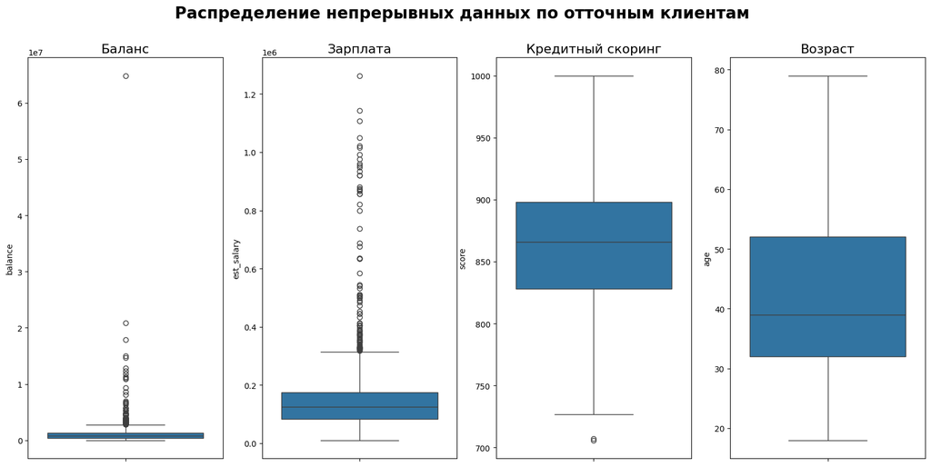

```python
plt.figure(figsize=(20, 9))
plt.suptitle('Распределение непрерывных данных по отточным клиентам', fontweight='bold', fontsize=20)
ax1 = plt.subplot(1, 4, 1)
ax1.set_title('Баланс', fontsize=16)
ax1 = sns.boxplot(y=bank_churn['balance'])
ax2 = plt.subplot(1, 4, 2)
ax2.set_title('Зарплата', fontsize=16)
ax2 = sns.boxplot(y=bank_churn['est_salary'])
ax3 = plt.subplot(1, 4, 3)
ax3.set_title('Кредитный скоринг', fontsize=16)
ax3 = sns.boxplot(y=bank_churn['score'])
ax3 = plt.subplot(1, 4, 4)
ax3.set_title('Возраст', fontsize=16)
ax3 = sns.boxplot(y=bank_churn['age'])
```

Проверим наличие выбросов в непрерывных данных по неотточным клиентам.

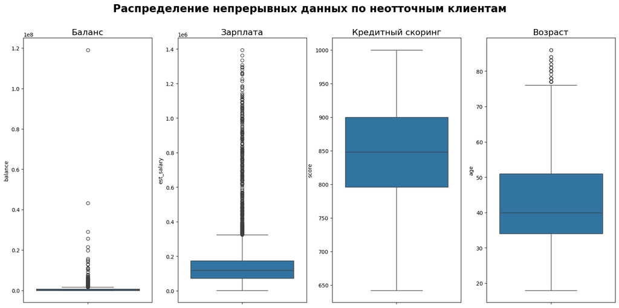

```python
plt.figure(figsize=(20, 9))
plt.suptitle('Распределение непрерывных данных по неотточным клиентам', fontweight='bold', fontsize=20)
ax1 = plt.subplot(1, 4, 1)
ax1.set_title('Баланс', fontsize=16)
ax1 = sns.boxplot(y=bank_hold['balance'])
ax2 = plt.subplot(1, 4, 2)
ax2.set_title('Зарплата', fontsize=16)
ax2 = sns.boxplot(y=bank_hold['est_salary'])
ax3 = plt.subplot(1, 4, 3)
ax3.set_title('Кредитный скоринг', fontsize=16)
ax3 = sns.boxplot(y=bank_hold['score'])
ax3 = plt.subplot(1, 4, 4)
ax3.set_title('Возраст', fontsize=16)
ax3 = sns.boxplot(y=bank_hold['age'])
```

В обоих случаях есть большое количество значений, лежащих выше верхней границы диаграммы размаха, в данных по балансу и зарплате. Эти выбросы не являются ошибками, они отражают, что есть значительная разница между высокими и низкими зарплатами и балансами клиентов, причем клиентов с высокими зарплатами и балансами значительно меньше, чем с низкими значениями этих параметров. Для таких параметров вдополнение к среднему рассчитаем медианное значение, чтобы отразить, в какую сторону смещено распределение.

Также есть небольшие выбросы меньше нижней границы диаграммы размаха в значениях кредитного скоринга у отточных клиентов и больше верхней границы диаграммы размаха по возрасту у неотточных клиентов. Эти выбрасы также не являются ошибками, но их мало и они не оказывают серьезного влияния на результаты анализа. Для этих параметров расчитаем только средние значения.

Дополнительно расчитаем абсолютную и относительную разницы соответствующих значений отточных и неотточных клиентов.

```python
clients_portraits = bank.groupby(['churn']).agg({'balance':['mean', 'median'],
                                                 'est_salary':['mean', 'median'],
                                                 'score':'mean',
                                                 'age':'mean',
                                                 'products':'mean'})
clients_portraits.columns = ('balance_mean',
                             'balance_median',
                             'salary_mean',
                             'salary_median',
                             'score_mean',
                             'age_mean',
                             'products_mean')
clients_portraits = clients_portraits.transpose().reset_index()
clients_portraits.columns = ('parameter', 'hold_client', 'churn_client')
clients_portraits['delta'] = clients_portraits['churn_client'] - clients_portraits['hold_client']
clients_portraits['delta, %'] = ((clients_portraits['churn_client'] - clients_portraits['hold_client'])/
                                   clients_portraits['hold_client']) * 100
clients_portraits = clients_portraits.round(2)
clients_portraits
```

|  | parameter | hold_client | churn_client | delta | delta, % |
| --- | --- | --- | --- | --- | --- |
| 0 | balance_mean | 529221.18 | 1125893.32 | 596672.13 | 112.75 |
| 1 | balance_median | 320687.93 | 775349.22 | 454661.28 | 141.78 |
| 2 | salary_mean | 147783.20 | 148243.01 | 459.81 | 0.31 |
| 3 | salary_median | 118257.72 | 125390.62 | 7132.90 | 6.03 |
| 4 | score_mean | 845.43 | 863.40 | 17.97 | 2.13 |
| 5 | age_mean | 43.01 | 41.45 | -1.56 | -3.63 |
| 6 | products_mean | 1.76 | 2.38 | 0.62 | 35.18 |

Для дискретных значений выведем моду.

```python
clients_portraits_disc = bank.groupby(['churn']).agg({'credit_card':pd.Series.mode,
                                                      'gender':pd.Series.mode})
clients_portraits_disc.columns = ('credit_card_mode',
                             'gender_code_mode')
clients_portraits_disc = clients_portraits_disc.transpose().reset_index()
clients_portraits_disc.columns = ('parameter', 'hold_client', 'churn_client')
clients_portraits_disc
```

|  | parameter | hold_client | churn_client |
| --- | --- | --- | --- |
| 0 | credit_card_mode | 1 | 1 |
| 1 | gender_code_mode | Ж | М |

Проверим на каких интервалах непрерывных данных отток выше.

Построим KDE-график данных о балансе.

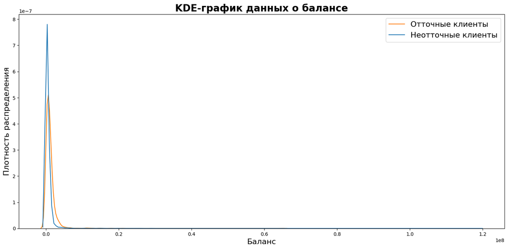

```python
plt.figure(figsize=(18, 8))
sns.kdeplot(data=bank, x='balance', hue='churn', common_norm=False)
plt.title('KDE-график данных о балансе', fontweight='bold', fontsize=20)
plt.xlabel('Баланс', fontsize=16)
plt.ylabel('Плотность распределения', fontsize=16)
plt.legend(['Отточные клиенты', 'Неотточные клиенты'], fontsize=16);
```

На этом графике крайне сложно точно определить точку пересечения линий. Для этого добавим еще один график с ограничением по оси Х.

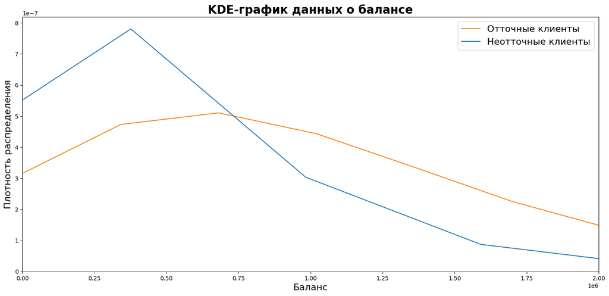

```python
plt.figure(figsize=(18, 8))
sns.kdeplot(data=bank, x='balance', hue='churn', common_norm=False)
plt.xlim(0, 2000000)
plt.title('KDE-график данных о балансе', fontweight='bold', fontsize=20)
plt.xlabel('Баланс', fontsize=16)
plt.ylabel('Плотность распределения', fontsize=16)
plt.legend(['Отточные клиенты', 'Неотточные клиенты'], fontsize=16);
```

На графике видно, что уровень оттока выше среди клиентов с балансом больше 750000 р.

Построим KDE-график данных о зарплате.

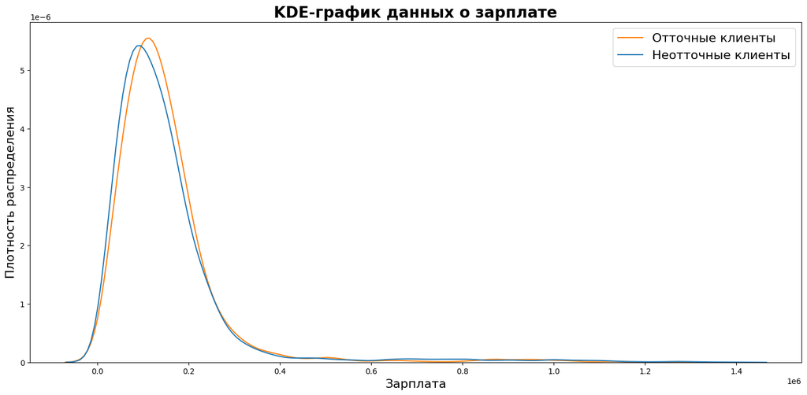

```python
plt.figure(figsize=(18, 8))
sns.kdeplot(data=bank, x='est_salary', hue='churn', common_norm=False)
plt.title('KDE-график данных о зарплате', fontweight='bold', fontsize=20)
plt.xlabel('Зарплата', fontsize=16)
plt.ylabel('Плотность распределения', fontsize=16)
plt.legend(['Отточные клиенты', 'Неотточные клиенты'], fontsize=16);
```

На этом графике видно, что в районе 100000 р. линия плотности распределения отточных клиентов пересекает линию плотности распредления неотточных клиентов снизу вверх, но затем снижается и опять пересекает линию плотности распределения неотточных клиентов. После этого линии находятся примерно на одном и том же уровне. Чтобы точнее определить точки пересечения линий, построим еще один график с ограничением по оси Х.

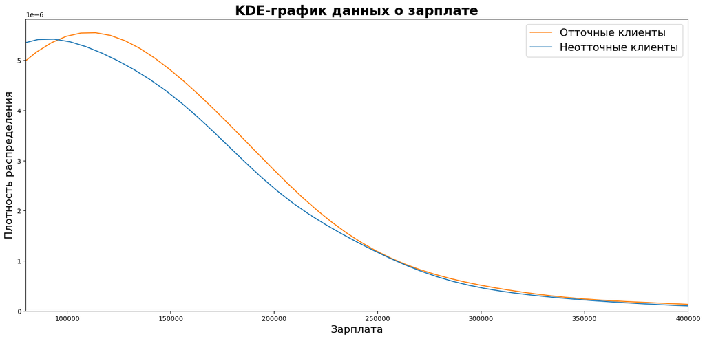

```python
plt.figure(figsize=(18, 8))
sns.kdeplot(data=bank, x='est_salary', hue='churn', common_norm=False)
plt.xlim(80000, 400000)
plt.title('KDE-график данных о зарплате', fontweight='bold', fontsize=20)
plt.xlabel('Зарплата', fontsize=16)
plt.ylabel('Плотность распределения', fontsize=16)
plt.legend(['Отточные клиенты', 'Неотточные клиенты'], fontsize=16);
```

На этом графике видно, что уровень оттока выше среди клиентов с зарплатой от 100000 р. до 250000 р.

Построим KDE-график данных о кредитном скоринге.

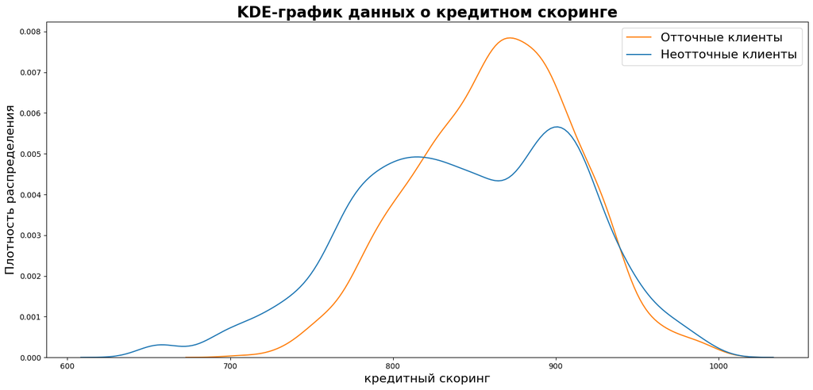

```python
plt.figure(figsize=(18, 8))
sns.kdeplot(data=bank, x='score', hue='churn', common_norm=False)
plt.title('KDE-график данных о кредитном скоринге', fontweight='bold', fontsize=20)
plt.xlabel('кредитный скоринг', fontsize=16)
plt.ylabel('Плотность распределения', fontsize=16)
plt.legend(['Отточные клиенты', 'Неотточные клиенты'], fontsize=16);
```

На графике видно, что уровень оттока выше среди клиентов с кредитным скорингом от 820 до 950 баллов.

Построим KDE-график данных о возрасте.

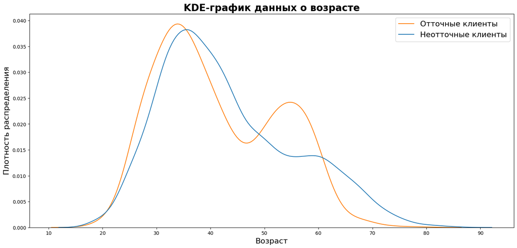

```python
plt.figure(figsize=(18, 8))
sns.kdeplot(data=bank, x='age', hue='churn', common_norm=False)
plt.title('KDE-график данных о возрасте', fontweight='bold', fontsize=20)
plt.xlabel('Возраст', fontsize=16)
plt.ylabel('Плотность распределения', fontsize=16)
plt.legend(['Отточные клиенты', 'Неотточные клиенты'], fontsize=16);
```

На графике видно, что уровень оттока выше среди клиентов в возрасте от 22 до 35 и от 50 до 62 лет.

Изучим незакодированные категориальные переменные.

```python
bank['city'].mode()
```

```
0    Ярославль
Name: city, dtype: object
```

Прверим доли оттока по категориальным признакам.

Посчитаем доли оттока по городу.

```python
churn_by_city = bank.pivot_table(index='city', values='churn', aggfunc='mean').reset_index()
churn_by_city.columns = ('city', 'churn_rate')
churn_by_city = churn_by_city.sort_values(by='churn_rate')
churn_by_city
```

|  | city | churn_rate |
| --- | --- | --- |
| 1 | Рыбинск | 0.162152 |
| 0 | Ростов | 0.187721 |
| 2 | Ярославль | 0.189708 |

Построим визуализацию.

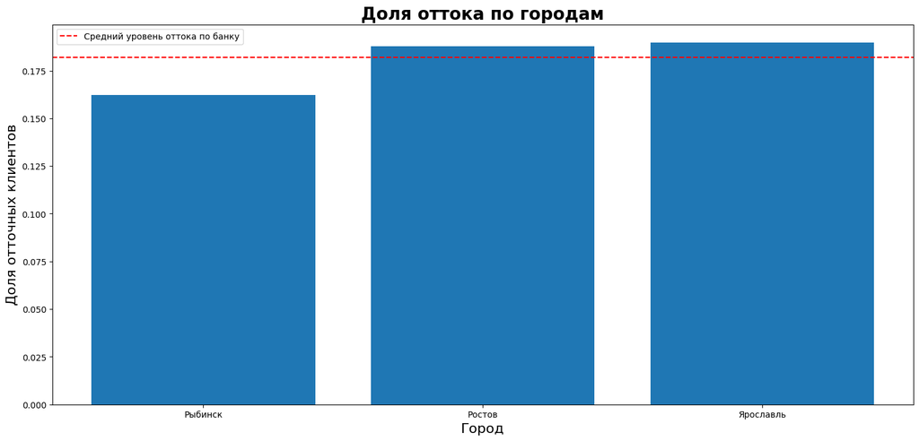

```python
plt.figure(figsize=(18, 8))
plt.bar(churn_by_city['city'], churn_by_city['churn_rate'])
plt.axhline(y=bank['churn'].mean(), color='r', linestyle='dashed', label='Средний уровень оттока по банку')
plt.title('Доля оттока по городам', fontweight='bold', fontsize=20)
plt.xlabel('Город', fontsize=16)
plt.ylabel('Доля отточных клиентов', fontsize=16)
plt.legend();
```

Уровень оттока клиентов по городу Рыбинск составляет 16.2%, что ниже среднего оттока по банку, а по городам Ростов и Ярославль - 18.8% и 19.0% соответственно, что выше среднего оттока по банку.

Посчитаем доли оттока по полу клиента.

```python
churn_by_gender = bank.pivot_table(index='gender', values='churn', aggfunc='mean').reset_index()
churn_by_gender.columns = ('gender', 'churn_rate')
churn_by_gender
```

|  | gender | churn_rate |
| --- | --- | --- |
| 0 | Ж | 0.127528 |
| 1 | М | 0.236364 |

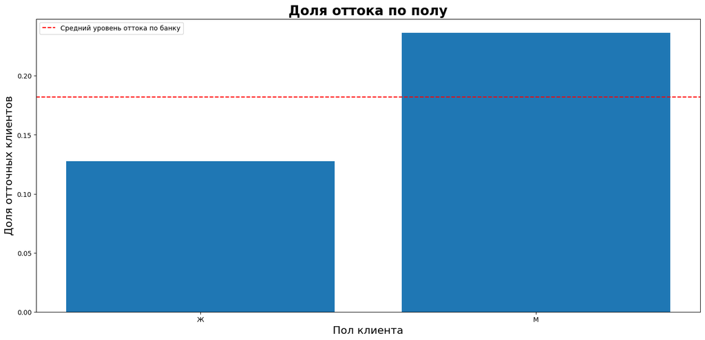

```python
plt.figure(figsize=(18, 8))
plt.bar(churn_by_gender['gender'], churn_by_gender['churn_rate'])
plt.axhline(y=bank['churn'].mean(), color='r', linestyle='dashed', label='Средний уровень оттока по банку')
plt.title('Доля оттока по полу', fontweight='bold', fontsize=20)
plt.xlabel('Пол клиента', fontsize=16)
plt.ylabel('Доля отточных клиентов', fontsize=16)
plt.legend();
```

Уровень оттока среди женщин составляет 12.8%, что ниже среднего оттока по банку, а среди мужчин - 23.6%, что выше среднего оттока по банку.

Посчитаем доли оттока по оценке собственности клиента.

```python
churn_by_equity = bank.pivot_table(index='equity', values='churn', aggfunc='mean').reset_index()
churn_by_equity.columns = ('equity', 'churn_rate')
churn_by_equity
```

|  | equity | churn_rate |
| --- | --- | --- |
| 0 | 0 | 0.034722 |
| 1 | 1 | 0.120155 |
| 2 | 2 | 0.157795 |
| 3 | 3 | 0.208684 |
| 4 | 4 | 0.250811 |
| 5 | 5 | 0.300834 |
| 6 | 6 | 0.360248 |
| 7 | 7 | 0.462500 |
| 8 | 8 | 0.352941 |
| 9 | 9 | 0.538462 |

Построим визуализацию.

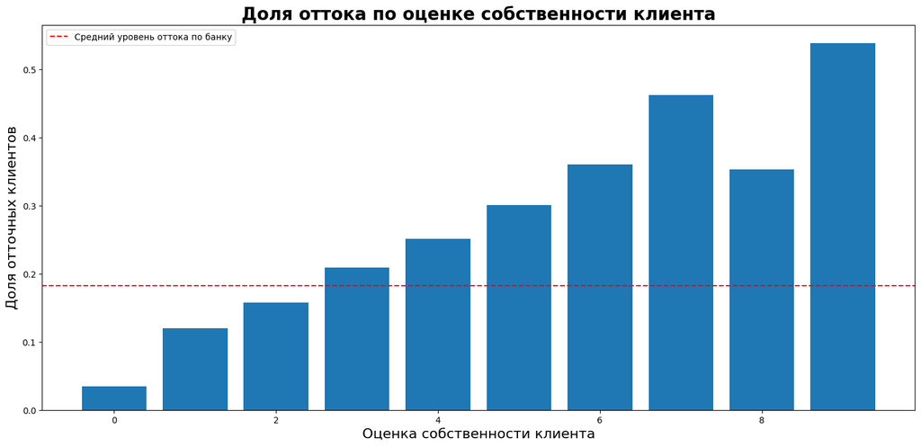

```python
plt.figure(figsize=(18, 8))
plt.bar(churn_by_equity['equity'], churn_by_equity['churn_rate'])
plt.axhline(y=bank['churn'].mean(), color='r', linestyle='dashed', label='Средний уровень оттока по банку')
plt.title('Доля оттока по оценке собственности клиента', fontweight='bold', fontsize=20)
plt.xlabel('Оценка собственности клиента', fontsize=16)
plt.ylabel('Доля отточных клиентов', fontsize=16)
plt.legend();
```

Посчитаем доли оттока по количеству продуктов, которыми пользуется клиент.

```python
churn_by_products = bank.pivot_table(index='products', values='churn', aggfunc='mean').reset_index()
churn_by_products.columns = ('products', 'churn_rate')
churn_by_products
```

|  | products | churn_rate |
| --- | --- | --- |
| 0 | 0 | 1.000000 |
| 1 | 1 | 0.070338 |
| 2 | 2 | 0.190987 |
| 3 | 3 | 0.285852 |
| 4 | 4 | 0.632911 |
| 5 | 5 | 0.421053 |

Построим визуализацию.

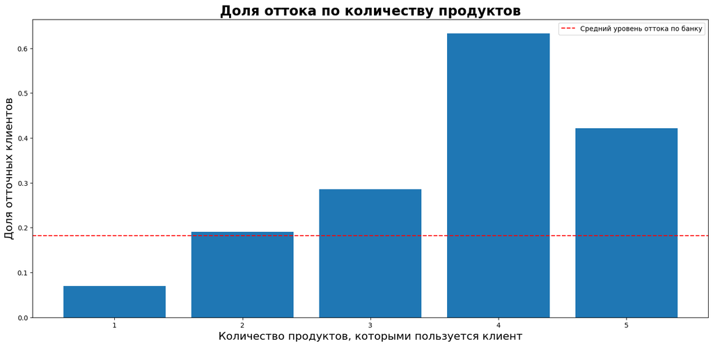

```python
plt.figure(figsize=(18, 8))
plt.bar(churn_by_products.query('products != 0')['products'], churn_by_products.query('products != 0')['churn_rate'])
plt.axhline(y=bank['churn'].mean(), color='r', linestyle='dashed', label='Средний уровень оттока по банку')
plt.title('Доля оттока по количеству продуктов', fontweight='bold', fontsize=20)
plt.xlabel('Количество продуктов, которыми пользуется клиент', fontsize=16)
plt.ylabel('Доля отточных клиентов', fontsize=16)
plt.legend();
```

Наименьший отток среди клиентов, у которыхтолько один продукт банка - 7.0%, наибольший - среди клиентов, у которых 4 продукта - 63.3%. Отток среди клиентов с 1 продуктом ниже среднего оттока по банку, среди клиентов с 2 продуктами и более - выше среднего оттока по банку.

Посчитаем доли оттока по наличию кредитной карты.

```python
churn_by_credit_card = bank.pivot_table(index='credit_card', values='churn', aggfunc='mean').reset_index()
churn_by_credit_card.columns = ('credit_card', 'churn_rate')
churn_by_credit_card['credit_card'] = ('Нет', 'Да')
churn_by_credit_card
```

|  | credit_card | churn_rate |
| --- | --- | --- |
| 0 | Нет | 0.255632 |
| 1 | Да | 0.147413 |

Построим визуализацию.

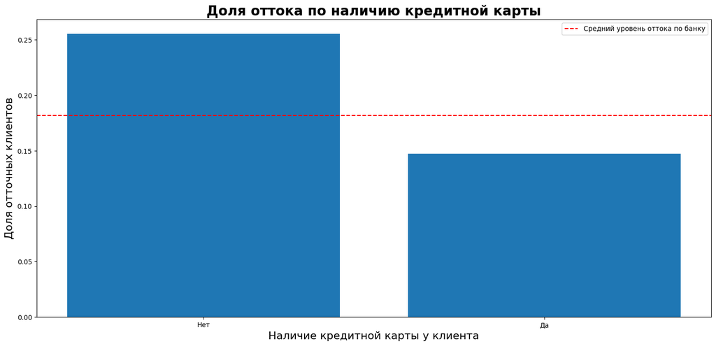

```python
plt.figure(figsize=(18, 8))
plt.bar(churn_by_credit_card['credit_card'], churn_by_credit_card['churn_rate'])
plt.axhline(y=bank['churn'].mean(), color='r', linestyle='dashed', label='Средний уровень оттока по банку')
plt.title('Доля оттока по наличию кредитной карты', fontweight='bold', fontsize=20)
plt.xlabel('Наличие кредитной карты у клиента', fontsize=16)
plt.ylabel('Доля отточных клиентов', fontsize=16)
plt.legend();
```

Посчитаем доли оттока по активности клиента за последнее время.

```python
churn_by_last_activity = bank.pivot_table(index='last_activity', values='churn', aggfunc='mean').reset_index()
churn_by_last_activity.columns = ('last_activity', 'churn_rate')
churn_by_last_activity['last_activity'] = ('Нет', 'Да')
churn_by_last_activity
```

|  | last_activity | churn_rate |
| --- | --- | --- |
| 0 | Нет | 0.113746 |
| 1 | Да | 0.244126 |

Построим визуализацию.

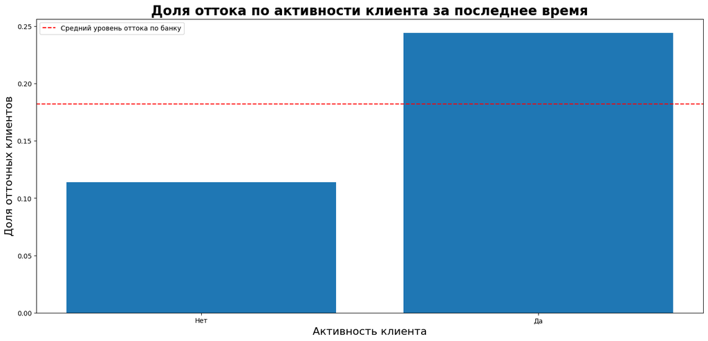

```python
plt.figure(figsize=(18, 8))
plt.bar(churn_by_last_activity['last_activity'], churn_by_last_activity['churn_rate'])
plt.axhline(y=bank['churn'].mean(), color='r', linestyle='dashed', label='Средний уровень оттока по банку')
plt.title('Доля оттока по активности клиента за последнее время', fontweight='bold', fontsize=20)
plt.xlabel('Активность клиента', fontsize=16)
plt.ylabel('Доля отточных клиентов', fontsize=16)
plt.legend();
```

Изучим корреляцию признаков клиентов.

Построим матрицу корреляции всех признаков таблицы.

```python
bank_matrix = bank.drop('user_id', axis=1)
correlation_matrix = bank_matrix.phik_matrix(interval_cols=['score', 'age', 'balance', 'est_salary'])
correlation_matrix = correlation_matrix.round(4)
correlation_matrix
```

|  | score | city | gender | age | equity | balance | products | credit_card | last_activity | est_salary | churn | gender_code | city_ros | city_ryb | city_yar |
| --- | --- | --- | --- | --- | --- | --- | --- | --- | --- | --- | --- | --- | --- | --- | --- |
| score | 1.0000 | 0.0910 | 0.0713 | 0.0320 | 0.5280 | 0.1452 | 0.3092 | 0.2087 | 0.0529 | 0.3957 | 0.2296 | 0.0713 | 0.0867 | 0.0277 | 0.0839 |
| city | 0.0910 | 1.0000 | 0.0127 | 0.0918 | 0.0634 | 0.0313 | 0.2226 | 0.0748 | 0.0305 | 0.1714 | 0.0168 | 0.0127 | 1.0000 | 1.0000 | 1.0000 |
| gender | 0.0713 | 0.0127 | 1.0000 | 0.2861 | 0.0646 | 0.0371 | 0.1225 | 0.1962 | 0.0142 | 0.1448 | 0.2188 | 1.0000 | 0.0170 | 0.0195 | 0.0360 |
| age | 0.0320 | 0.0918 | 0.2861 | 1.0000 | 0.0479 | 0.0196 | 0.1338 | 0.1576 | 0.0876 | 0.3593 | 0.1924 | 0.2861 | 0.0680 | 0.0580 | 0.0944 |
| equity | 0.5280 | 0.0634 | 0.0646 | 0.0479 | 1.0000 | 0.0000 | 0.4424 | 0.2219 | 0.0511 | 0.2865 | 0.3527 | 0.0646 | 0.0655 | 0.0000 | 0.0549 |
| balance | 0.1452 | 0.0313 | 0.0371 | 0.0196 | 0.0000 | 1.0000 | 0.0000 | 0.0000 | 0.0000 | 0.2176 | 0.0344 | 0.0371 | 0.0000 | 0.0198 | 0.0400 |
| products | 0.3092 | 0.2226 | 0.1225 | 0.1338 | 0.4424 | 0.0000 | 1.0000 | 0.4592 | 0.1914 | 0.1579 | 0.4414 | 0.1225 | 0.0759 | 0.1453 | 0.1839 |
| credit_card | 0.2087 | 0.0748 | 0.1962 | 0.1576 | 0.2219 | 0.0000 | 0.4592 | 1.0000 | 0.0498 | 0.0382 | 0.2030 | 0.1962 | 0.1528 | 0.0767 | 0.1786 |
| last_activity | 0.0529 | 0.0305 | 0.0142 | 0.0876 | 0.0511 | 0.0000 | 0.1914 | 0.0498 | 1.0000 | 0.0461 | 0.2612 | 0.0142 | 0.0000 | 0.0746 | 0.0749 |
| est_salary | 0.3957 | 0.1714 | 0.1448 | 0.3593 | 0.2865 | 0.2176 | 0.1579 | 0.0382 | 0.0461 | 1.0000 | 0.0477 | 0.1448 | 0.1362 | 0.1016 | 0.1762 |
| churn | 0.2296 | 0.0168 | 0.2188 | 0.1924 | 0.3527 | 0.0344 | 0.4414 | 0.2030 | 0.2612 | 0.0477 | 1.0000 | 0.2188 | 0.0000 | 0.0460 | 0.0336 |
| gender_code | 0.0713 | 0.0127 | 1.0000 | 0.2861 | 0.0646 | 0.0371 | 0.1225 | 0.1962 | 0.0142 | 0.1448 | 0.2188 | 1.0000 | 0.0170 | 0.0195 | 0.0360 |
| city_ros | 0.0867 | 1.0000 | 0.0170 | 0.0680 | 0.0655 | 0.0000 | 0.0759 | 0.1528 | 0.0000 | 0.1362 | 0.0000 | 0.0170 | 1.0000 | 0.3773 | 0.6912 |
| city_ryb | 0.0277 | 1.0000 | 0.0195 | 0.0580 | 0.0000 | 0.0198 | 0.1453 | 0.0767 | 0.0746 | 0.1016 | 0.0460 | 0.0195 | 0.3773 | 1.0000 | 0.9092 |
| city_yar | 0.0839 | 1.0000 | 0.0360 | 0.0944 | 0.0549 | 0.0400 | 0.1839 | 0.1786 | 0.0749 | 0.1762 | 0.0336 | 0.0360 | 0.6912 | 0.9092 | 1.0000 |

Построим визуализацию в виде тепловой карты.

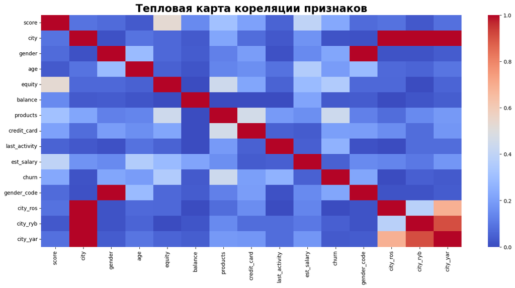

```python
plt.figure(figsize=(18, 8))
sns.heatmap(correlation_matrix, cmap='coolwarm')
plt.title('Тепловая карта кореляции признаков', fontweight='bold', fontsize=20);
```

Также добавим столбец корреляции всех признаков с признаком оттока.

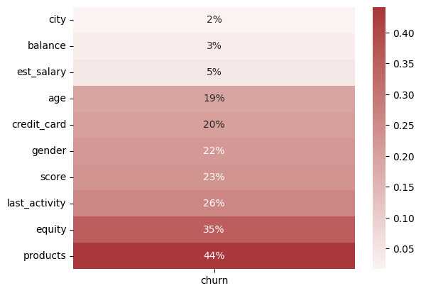

```python
sns.heatmap(correlation_matrix.loc[:,['churn']].drop(['churn','city_ros', 'city_yar', 'city_ryb', 'gender_code']).
            sort_values('churn'), annot=True, fmt=".0%", cmap='vlag', center=0);
```

На данном этапе сравнили портреты типичных отточных и неотточных клиентов по непрерывным данным (балансу, зарпате, кредитному скоррингу и возрасту). Установили, что отточные и неотточные клиенты значительно отличаются по среднему значению баласа (1125893.32 р. и 529221.18 р. соответственно, разница составляет 596672.14 р.), медианному значению баланса (775349.22 р. и 320687.93 р. соответственно, разница составляет 454661.29 р.). В то же время у отточных и неотточных клиентов нет значительной разницы в среднем уровне зарплаты (148243.01 р. и 147783.20 р. соответственно, разница составляет 459.81 р.) и медианном уровне зарплаты (125390.62 р. и 118257.72 р. соответственно, разница составляет 7132.90 р.). Также между отточными и неотточными клиентами нет значительной разницы в средних значениях кредитного скоринга (863.40 балла и 845.43 балла соответственно, разница составляет 17.97 балла) и средних значениях возраста (41.45 года и 43.01 года соответственно, отточные клиенты младше неотточных в среднем на 1.56 года). Средние значения колличества продуктов у отточных и неотточных клиентов различны (1.76 и 2.38 соответственно, разница составляет 0.62). Наиболее часто встречающее значение, характеризующее наличие кредитной карты у клиента, у отточных и неотточных клиентов одинаковое - 1 - есть кредитная карта. Наиболее часто встречающееся значение гендера у отточных клиентов 1 (мужчина), у неотточных - 0 (женщина).

Также было проверено, на каких интервалах непрерывных данных отток выше с поммощью KDE-графиков, и установлено, что отток клиентов в зависимости от признака выше в следующих интервалах:

- по балансу - выше 750000 р.;
- по зарплате - от 100000 р. до 250000 р.;
- по баллам кредитного скоринга - от 820 до 950 баллов;
- по возрасту - от 22 до 35 и от 50 до 62 лет.

Изучив незакодированные категориальные переменные, было установлено, что больше всего отточных клиентов из Ярославля, и сто среди отточных клиентов большую часть составляют мужчины.

## Проверка статистических гипотез

**Проверим гипотезу различия дохода между отточными и неотточными клиентами.**

Для этого воспользуемся методами проерки гипотезы о равенстве средних двух генеральных совокупностей с применением t-критерия Стьюдента u-критерия Манна-Уитни.

Т-критерий Стьюдента обычно применяется для проверки равенства средних значений в двух выборках. Для применения данного критерия необходимо, чтобы выборочные средние имели нормальное распределение и данных не было значительного числа выбросов.

U-критерий Манна-Уитни также является статистическим критерием, используемым для оценки различий между двумя независимыми выборками. Применяется при несоблюдении требований к данным для t-критерия Манна-Уитни. Позволяет выявлять различия в значении параметра между малыми выборками. Для применения данного критерия требуется, чтобы в выборочных данных не бытло совпадающих значений или таких совпадений бытло очень мало (до 10).

Сформулируем нулевую и альтернативную гипотезы:

- H0 - уровень дохода отточных и неотточных клиентов одинаковый.
- Н1 - уровень дохода отточных и неотточных клиентов разный.

Выборка зарплат отточных клиентов

```python
churn_salary = bank_churn['est_salary']
```

Среднее значение зарплаты неотточных клиентов

```python
hold_salary = bank_hold['est_salary']
```

Примем уровень статистической значимости равным 5%.

```python
alpha = 0.05
```

Проверяем гипотезу с применением t-критерия Стьюдента.

```python
results = st.ttest_ind(
    churn_salary,
    hold_salary)

print('p-значение:', results.pvalue)

if (results.pvalue < alpha):
    print('Отвергаем нулевую гипотезу: уровень дохода отточных и неотточных клиентов разный.')
else:
    print('Не отвергаем нулевую гипотезу: уровень дохода отточных и неотточных клиентов одинаковый.')
```

```
p-значение: 0.8987254468291451
Не отвергаем нулевую гипотезу: уровень дохода отточных и неотточных клиентов одинаковый.
```

Прверяем гипотезу с применением u-критерия Манна-Уитни.

```python
results = st.mannwhitneyu(
    churn_salary,
    hold_salary)

print('p-значение:', results.pvalue)

if (results.pvalue < alpha):
    print('Отвергаем нулевую гипотезу: уровень дохода отточных и неотточных клиентов разный.')
else:
    print('Не отвергаем нулевую гипотезу: уровень дохода отточных и неотточных клиентов одинаковый.')
```

```
p-значение: 0.000243559272811695
Отвергаем нулевую гипотезу: уровень дохода отточных и неотточных клиентов разный.
```

Критерии дали разные результаты. T-критерий Стьюдента применим для данных с нормальным распределением, а u-критереий Манна-Уитни может использоватся для данных с большим количеством выбросов. В данных по зарплате выбрасов много, такое распределение нельзя назвать нормальным. Повторим тесты еще раз, отбросив большую часть выбросов.

```python
churn_salary_clean = bank_churn.query('est_salary <= 350000')['est_salary']
hold_salary_clean = bank_hold.query('est_salary <= 350000')['est_salary']
```

Проверяем гипотезу на очищенных данных с применением t-критерия Стьюдента.

```python
results = st.ttest_ind(
    churn_salary_clean,
    hold_salary_clean)

print('p-значение:', results.pvalue)

if (results.pvalue < alpha):
    print('Отвергаем нулевую гипотезу: уровень дохода отточных и неотточных клиентов разный.')
else:
    print('Не отвергаем нулевую гипотезу: уровень дохода отточных и неотточных клиентов одинаковый.')
```

```
p-значение: 0.0002891919667177487
Отвергаем нулевую гипотезу: уровень дохода отточных и неотточных клиентов разный.
```

Прверяем гипотезу на очищенных данных с применением u-критерия Манна-Уитни.

```python
results = st.mannwhitneyu(
    churn_salary_clean,
    hold_salary_clean)

print('p-значение:', results.pvalue)

if (results.pvalue < alpha):
    print('Отвергаем нулевую гипотезу: уровень дохода отточных и неотточных клиентов разный.')
else:
    print('Не отвергаем нулевую гипотезу: уровень дохода отточных и неотточных клиентов одинаковый.')
```

```
p-значение: 1.3414323751522884e-05
Отвергаем нулевую гипотезу: уровень дохода отточных и неотточных клиентов разный.
```

После очистки данных от выбросов результаты проверки совпали, уровень дохода отточных и неотточных клиентов разный.

Для проверки выведем значения средней зарплаты отточных и неотточных клиентов.

```python
print('Среднее значение зарплаты отточных клиентов равно', round(bank_churn['est_salary'].mean(), 2), 'р.')
print('Среднее значение зарплаты неотточных клиентов равно', round(bank_hold['est_salary'].mean(), 2), 'р.')
```

```
Среднее значение зарплаты отточных клиентов равно 148243.01 р.
Среднее значение зарплаты неотточных клиентов равно 147783.2 р.
```

**Проверим гипотезу о том, что баланс отточных клиентов больше баланса неотточных клиентов.**

Для этого воспользуемся методами проерки гипотезы о равенстве средних двух генеральных совокупностей.

Сформулируем нулевую и альтернативную гипотезы:

- H0 - баланс отточных и неотточных клиентов одинаковый.
- Н1 - баланс отточных клиентов больше баланса неотточных клиентов.

Выборка балансов отточных клиентов

```python
churn_balance = bank_churn['balance']
```

Среднее значение баланса неотточных клиентов

```python
hold_balance = bank_hold['balance']
```

Примем уровень статистической значимости равным 5%.

```python
alpha = 0.05
```

Проверяем одностороннюю гипотезу с применением t-критерия Стьюдента.

```python
results = st.ttest_ind(
    churn_balance,
    hold_balance,
    alternative='greater')

print('p-значение:', results.pvalue)

if (results.pvalue < alpha):
    print('Отвергаем нулевую гипотезу: баланс отточных клиентов больше баланса неотточных клиентов.')
else:
    print('Не отвергаем нулевую гипотезу: баланс отточных и неотточных клиентов одинаковый.')
```

```
p-значение: 3.6722807596892236e-39
Отвергаем нулевую гипотезу: баланс отточных клиентов больше баланса неотточных клиентов.
```

Прверяем одностороннюю гипотезу с применением u-критерия Манна-Уитни.

```python
results = st.mannwhitneyu(
    churn_balance,
    hold_balance,
    alternative='greater')

print('p-значение:', results.pvalue)

if (results.pvalue < alpha):
    print('Отвергаем нулевую гипотезу: баланс отточных клиентов больше баланса неотточных клиентов.')
else:
    print('Не отвергаем нулевую гипотезу: баланс отточных и неотточных клиентов одинаковый.')
```

```
p-значение: 1.9531961847556372e-218
Отвергаем нулевую гипотезу: баланс отточных клиентов больше баланса неотточных клиентов.
```

В данном случае результаты проверки совпали, баланс отточных клиентов больше баланса неотточных клиентов.

Для проверки выведем значения средней балансов отточных и неотточных клиентов.

```python
print('Среднее значение баланса отточных клиентов равно', round(bank_churn['balance'].mean(), 2), 'р.')
print(f'Среднее значение баланса неотточных клиентов равно', round(bank_hold['balance'].mean(), 2), 'р.')
```

```
Среднее значение баланса отточных клиентов равно 1125893.32 р.
Среднее значение баланса неотточных клиентов равно 529221.18 р.
```

**Проверим гипотезу о равенстве доли мужчин и женщин среди отточных и неотточных клиентов.**

Для проверки гипотез о бинарных признаках будем использовать z-критерий двух пропорций, который основан на вычислении отношения разницы между случайной величиной и математическим ожиданием к стандартной ошибке этой случайной величины, т.е. показывает, является ли разница между двумя выборками статистически значмой. Для применения данного критерия необходимо, чтобы исходные данные имели нормальное распределение и была известна дисперсия генеральной совокупности.

Сформулируем нулевую и альтернативную гипотезы (достаточно проверить гипотезу о равенстве доли мужчин среди отточных и неотточных клиентов):

- H0 - доля мужчин среди отточных и неотточных клиентов одинаковая.
- Н1 - доля мужчин среди отточных и неотточных клиентов разная.

Объявим функцию для проведения теста.

```python
def ztest(g1, g2, n1, n2, alpha):
    p1 = n1/g1
    p2 = n2/g2
    p_combined = (n1 + n2) / (g1 + g2)
    difference = p1 - p2
    z_value = difference / mth.sqrt(p_combined * (1 - p_combined) * (1/g1 + 1/g2))
    distr = st.norm(0, 1)
    p_value = (1 - distr.cdf(abs(z_value))) * 2
    if p_value < alpha:
        print('Отвергаем нулевую гипотезу:  между долями пользователей в группах есть статистически значимая разница')
    else:
        print('Не можем отвергнуть нулевую гипотезу: между долями пользователей в группах нет статистически значимой разницы')
    print('p-value =', p_value, 'при alpha =', alpha)
```

Подготовим данные для проведения теста:

- количество отточных клиентов;
- количество неотточных клиентов;
- количество мужчин среди отточных клиентов;
- количество мужчин среди неотточных клиентов.

```python
bank_churn_clients = bank_churn['user_id'].count()
bank_hold_clients = bank_hold['user_id'].count()
bank_churn_clients_male = bank_churn['gender_code'].sum()
bank_hold_clients_male = bank_hold['gender_code'].sum()
```

Проведем тест.

```python
ztest(bank_churn_clients, bank_hold_clients, bank_churn_clients_male, bank_hold_clients_male, alpha)
```

```
Отвергаем нулевую гипотезу:  между долями пользователей в группах есть статистически значимая разница
p-value = 0.0 при alpha = 0.05
```

Для проверки выведем доли мужчин среди отточных и неотточных клиентов.

```python
print('Доля мужчин среди отточных клиентов равна', round(bank_churn_clients_male/bank_churn_clients, 2))
print('Доля мужчин среди неотточных клиентов равна', round(bank_hold_clients_male/bank_hold_clients, 2))
```

```
Доля мужчин среди отточных клиентов равна 0.65
Доля мужчин среди неотточных клиентов равна 0.47
```

**Проверим гипотезу о равенстве доли клиентов с кредитной картой среди отточных и неотточных клиентов.**

Также будем использовать z-критерий двух пропорций.

Подготовим данные для проведения теста.

```python
bank_churn_clients_credit = bank_churn['credit_card'].sum()
bank_hold_clients_credit = bank_hold['credit_card'].sum()
```

Проведем тест.

```python
ztest(bank_churn_clients, bank_hold_clients, bank_churn_clients_credit, bank_hold_clients_credit, alpha)
```

```
Отвергаем нулевую гипотезу:  между долями пользователей в группах есть статистически значимая разница
p-value = 0.0 при alpha = 0.05
```

Для проверки выведем доли клиентов с кредитной картой среди отточных и неотточных клиентов.

```python
print('Доля клиентов с кредитной картой среди отточных клиентов равна', round(bank_churn_clients_credit/bank_churn_clients, 2))
print('Доля клиентов с кредитной картой среди неотточных клиентов равна', round(bank_hold_clients_credit/bank_hold_clients, 2))
```

```
Доля клиентов с кредитной картой среди отточных клиентов равна 0.55
Доля клиентов с кредитной картой среди неотточных клиентов равна 0.71
```

По итогу проверки гипотез было установлено, что:

- уровень дохода отточных и неотточных клиентов разный;
- баланс отточных клиентов больше баланса неотточных клиентов;
- доля мужчин среди отточных и неотточных клиентов разная;
- доля клиентов с кредитной картой среди отточных и неотточных клиентов разная.

## Промежуточный итог

По результататм исследовательского и статистического анализа данных можно сделать следующие выводы:

[output not shown]

## Сегментация клиентов на основе стратегических показателей

В первый сегмент выделим клиентов, у которых нет кредитной карты, но которые в то же время обладают высоким кредитным скорингом и были активны в последнее время.

```python
bank.query('credit_card==0 and score>820 and score<950 and last_activity==1').agg({"churn":["mean","sum","count"]})
```

|  | churn |
| --- | --- |
| mean | 0.457358 |
| sum | 547.000000 |
| count | 1196.000000 |

Размер сегмента составляет 1196 клиентов, уровень оттока 45.7%, отточных клиентов 547.

Во второй сегмент выделим клиентов с балансом более 200000 р., уровнем дохода от 100000 р. до 250000 р. в возрасте от 50 до 62 лет.

```python
bank.query('balance>200000 and est_salary>=100000 and est_salary<250000 and age>=50 and age<=62').agg({"churn":["mean","sum","count"]})
```

|  | churn |
| --- | --- |
| mean | 0.380259 |
| sum | 235.000000 |
| count | 618.000000 |

Размер сегмента составляет 618 клиентов, уровень оттока 38.0%, отточных клиентов 235.

В третий сегмент выделим клиентов, у которых еще нет кредитной карты, с зарплатой от 100000 р. в возрасте от 25 до 35 лет.

```python
bank.query('est_salary >=100000 and age>=25 and age<=35 and credit_card==0').agg({"churn":["mean","sum","count"]})
```

|  | churn |
| --- | --- |
| mean | 0.434884 |
| sum | 187.000000 |
| count | 430.000000 |

Размер сегмента составляет 430 клиентов, уровень оттока 43.5%, отточных клиентов 187.

В четвертый сегмент выделим клиентов с высоким балансом (более 750000 р.) и высокой зарплатой (более 250000 р.).

```python
bank.query('balance>750000 and est_salary>250000').agg({"churn":["mean","sum","count"]})
```

|  | churn |
| --- | --- |
| mean | 0.440789 |
| sum | 134.000000 |
| count | 304.000000 |

Размер сегмента составляет 304 клиентов, уровень оттока 44.1%, отточных клиентов 134.

Сегменты приоритизированы по количеству отточных клиентов. Уровень оттока в каждом сегменьте выше общего уровня оттока 18.2%. Сегменты выделены таким образом, чтобы пересечение было минимальным. Общее количество отточных клиентов в выделенных сегментах составляет 1103.

## Общие выводы и рекомендации

В ходе работы над проектом был загружен и изучен датасет с данными о клиентах банка, который содержит 10000 строк и 12 столбцов.

На первом этапе названия столбцов были приведены к `snake_case`. Исходные данные содержали пропуски (в столбце `age` 26 пропусков, в столбце `balance` 2295 пропусков), которые были проанализированы и обработаны пропуски (в столбце `age` пропуски были заменены на медианное значение, в столбце `balance` - на 0). Явные дубликаты в датасете отсутствовали, неявные дубликаты были проанализированы (в столбце `user_id` дубликаты были оставлены без изменения, т.к. это не влияет на дальнейший анализ). В датасет были добавлены столбцы с обозначением пола и принадлежностью клиента к городу методом кодирования с помощью эффективных переменных.

После этого был проведен исследовательский анализ данных, в ходе которого были получены портреты типичных отточных и неотточных клиентов по непрерывным данным (балансу, зарпате, кредитному скоррингу и возрасту). Было установлено, что отточные и неотточные клиенты значительно отличаются по среднему значению баласа (1125893.32 р. и 529221.18 р. соответственно, разница составляет 596672.14 р.), медианному значению баланса (775349.22 р. и 320687.93 р. соответственно, разница составляет 454661.29 р.). В то же время у отточных и неотточных клиентов нет значительной разницы в среднем уровне зарплаты (148243.01 р. и 147783.20 р. соответственно, разница составляет 459.81 р.) и медианном уровне зарплаты (125390.62 р. и 118257.72 р. соответственно, разница составляет 7132.90 р.). Также между отточными и неотточными клиентами нет значительной разницы в средних значениях кредитного скоринга (863.40 балла и 845.43 балла соответственно, разница составляет 17.97 балла) и средних значениях возраста (41.45 года и 43.01 года соответственно, отточные клиенты младше неотточных в среднем на 1.56 года). Средние значения колличества продуктов у отточных и неотточных клиентов различны (1.76 и 2.38 соответственно, разница составляет 0.62). Наиболее часто встречающее значение, характеризующее наличие кредитной карты у клиента, у отточных и неотточных клиентов одинаковое - 1 - есть кредитная карта. Наиболее часто встречающееся значение гендера у отточных клиентов 1 (мужчина), у неотточных - 0 (женщина).

Также было проверено, на каких интервалах непрерывных данных отток выше с поммощью KDE-графиков, и установлено, что отток клиентов в зависимости от признака выше в следующих интервалах:

- по балансу - выше 750000 р.;
- по зарплате - от 100000 р. до 250000 р.;
- по баллам кредитного скоринга - от 820 до 950 баллов;
- по возрасту - от 22 до 35 и от 50 до 62 лет.

Изучив незакодированные категориальные переменные, было установлено, что больше всего отточных клиентов из Ярославля, и сто среди отточных клиентов большую часть составляют мужчины.

На следующем этапе была проведена проверка статистических гипотез и установлено, что:

- уровень дохода отточных и неотточных клиентов разный;
- баланс отточных клиентов больше баланса неотточных клиентов;
- доля мужчин среди отточных и неотточных клиентов разная;
- доля клиентов с кредитной картой среди отточных и неотточных клиентов разная.

После этого на основании результатов исследовательского и статистического анализа данных была проведена сегментацию пользователей на основе стратегических показателей: баланса, оценочной зарплаты клиента, баллов кредитного скоринга, возраста и наличия кредитной карты у клиента. Сегменты приоритизированы по количеству отточных клиентов. Уровень оттока в каждом сегменьте выше общего уровня оттока 18.2%. Сегменты выделены таким образом, чтобы пересечение было минимальным. Общее количество отточных клиентов в выделенных сегментах составляет 1103.

Для удержания клиентов, входящих в выделенные сегменты можно предложить описанные ниже мероприятия.

Для первого сегмента, состоящего из клиентов, у которых пока нет кредитной карты, но которые в то же время обладают высоким кредитным скорингом и были активны в последнее время, можно сделать предложение кредитной карты с бесплатным обслушиванием, расширенным кредитным лимитом, возможностью снятия наличных и переводов без комиссии и беспроцентным периодом 180 дней.

Для второго сегмента, состоящего из клиентов с балансом более 200000 р., уровнем дохода от 100000 р. до 250000 р. в возрасте от 50 до 62 лет, можно предложить программу пенсионного страхования, заплатную карту с повышенным кэшбэком на покупки в категориях супермаркеты и аптеки и подписку на сервис Яндекс Здоровье.

Для третьего сегмента, состоящего из клиентов, у которых еще нет кредитной карты, с зарплатой от 100000 р. в возрасте от 25 до 35 лет, можно предложить кредитную карту с бесплатным обслуживанием и повышенным кешбэком на покупки в категориях развлечения, образование, товары для дома и товары для детей. А также предоставить бесплатную подписку на Яндекс Плюс.

Для четвертого сегмента, состоящего из клиентов с высоким балансоми высокой зарплатой можно предложить вклад с повышенным прогрессивным процентом от суммы вклада и бесплатной программой лояльности при сумме вклада от 1000000 р.